# Homework 8

Ian Taylor Booth

4/28/2021

1. Fit an N-mixture model that assumes abundance is a function of wetland size and type, and detection probability is a function of sky and time

```r
library(unmarked)
y <- read.csv("sosp_nmix.csv")
site_covs <- read.csv("n_covs_nmix.csv")
p_covs <- read.csv("p_covs_nmix.csv")

det_covs <- list(
  time = data.frame(p_covs[, c('time.1', 'time.2')]),
  sky = data.frame(sky.1 = factor(p_covs$sky.1),
                   sky.2 = factor(p_covs$sky.2))
)

site_covs$herb <- factor(site_covs$herb)
site_covs$shrub1 <- factor(site_covs$shrub1)
site_covs$bareground <- factor(site_covs$bareground)
site_covs$shrub5 <- factor(site_covs$shrub5)

nmix_data <- unmarkedFramePCount (y = as.matrix(y),
                                 siteCovs = site_covs,
                                 obsCovs = det_covs)
fit <- pcount(~ sky + time ~ size + type, nmix_data, K = 100)
```

2. Write a function that calculates the sum of squared Pearson residuals from a fitted model.

```r
fitstats <- function(fit)
  {
  obs <- getY(fit)
  ex <- fitted(fit)
  det <- predict(fit, type = "det")
  dm <- matrix(det$Predicted, byrow = TRUE, ncol = 2)
  ts <- (obs - (ex)) ^ 2 /  ((ex) * (1 - dm))
  return(sum(ts))
}
```

3. Use the parboot() function in R to simulate the distribution of this test statistic under the assumption that your fitted model is the data-generating model. Simulate 1000 values of the test statistic. Note that this may take several minutes

```r
pb <- parboot(fit, fitstats, nsim=1000)
pb
```

```
##
## Call: parboot(object = fit, statistic = fitstats, nsim = 1000)
##
## Parametric Bootstrap Statistics:
##     t0 mean(t0 - t_B) StdDev(t0 - t_B) Pr(t_B > t0)
## 1 1026            643             35.7            0
##
## t_B quantiles:
##       0% 2.5% 25% 50% 75% 97.5% 100%
## [1,] 290  324 358 380 406   461  518
##
## t0 = Original statistic computed from data
## t_B = Vector of bootstrap samples
```

4. Plot the distribution of the simulated test statistic. Include in this plot the value of your test statistic calculated from your fitted model. What is the null hypothesis you are testing when conducting model checking? Do you reject or fail to reject this null hypothesis? What are the implications for how well you model fits the data

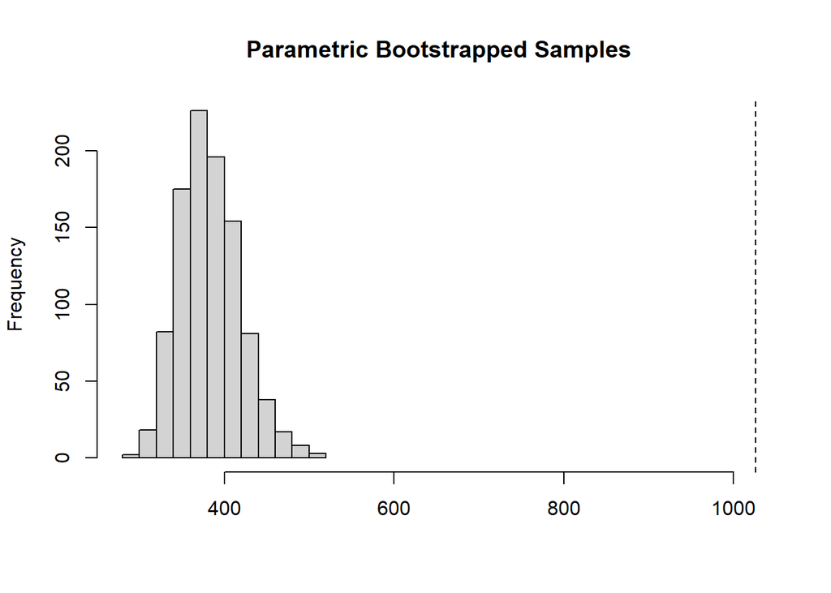

```r
plot(pb)
```